# Clase-9

Amaury Gutiérrez

5/1/2018

## R Markdown

Hasta ahora nos hemos enfocado en la parte del análisis de datos usando R. Este análisis no es útil si no se cominica de forma adecuada. Usualmente los reportes se hacen en Word o alguna otra herramienta de procesamiento de texto. En la última clase del curso introduciremos una alternativa para crear reportes llamada RMarkdown. Crear reportes con R ofrece algunas ventajas que enlistamos a continuación:

- Permite comunicar los resultados de un análisis a los tomadores de decisión sin exponer los detalles técnicos ni el codigo detrás del análisis.
- Facilita la colaboración entre distintas personas permitiendo expresar en un proceso (reproducible) el anális de los datos.
- Intercalando texto y el código que se aplica sobre los datos se puede dar un panorama más amplio sobre lo que se estaba pensando cuando se escribió el código.

### Crear un documento

Para crear un documento RMarkdown con RStudio se especifíca el tipo de documento como RMarkdown al crear el archivo. Por ahora escogeremos HTML como formato de salida (la creación de PDF requiere paquetería externa y está fuera del alcance del curso). RStudio creará una plantilla con todo lo necesario para compilar el documento. RStudio instalará y cargará el paquete *rmarkdown* cuando sea necesario. Si queremos seguir el proceso de instalación que hemos usado para otros paquetes también es posible:

```r
install.packages("rmarkdown")
```

Después de crear nuestro documento podemos usar el botón con una madeja de estambre y el texto *Knit* y ver el resultado.

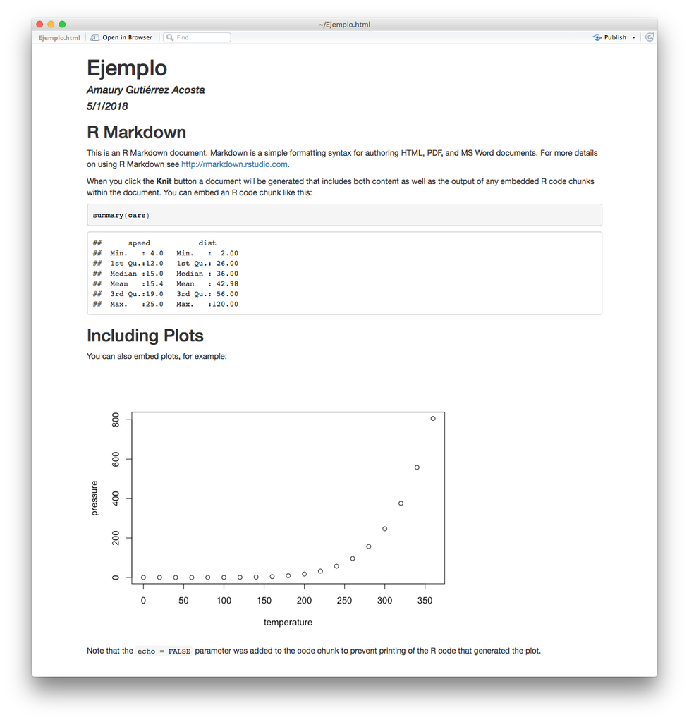

RStudio genera un archivo html auto-contenido que puede abrirse en cualquier navegador. Adicionalmente nos presenta una visualización del resultado. Analicemos ahora el contenido de nuestro archivo RMarkdown. Primero existe un header con información sobre el archivo como el título y el autor:

```
---
title: "Ejemplo"
author: "Amaury Gutiérrez Acosta"
date: "5/1/2018"
output: html_document
---
```

En general no modificaremos este contenido más que al principio del reporte. Otro tipo de contenido lo encontramos imediatamente en la forma de:

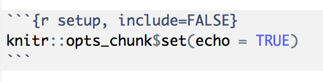

```r
2 + 2 # Se ejecuta y se muestra el resultado en el documento.
```

```
## [1] 4
```

```r
2 + 2 # No se ejecuta, aparece únicamente el bloque de código en el documento.
```

Por último encontramos un bloque de texto común y corriente:

```
## R Markdown

This is an R Markdown document. Markdown is a simple formatting syntax for authoring HTML, PDF, and MS Word documents. For more details on using R Markdown see <http://rmarkdown.rstudio.com>.

When you click the **Knit** button a document will be generated that includes both content as well as the output of any embedded R code chunks within the document. You can embed an R code chunk like this:
```

Notemos que tiene algunos decoradores en el texto que producen un resultado distinto en el archivo resultante.

Ejercicio 1: Analizar el resultado de la salida del documento y describir que hacen los decoradores en cada caso.

### Lenguaje Markdown

En esta sección detallaremos todos los decoradores de texto existentes en el lenguaje de marcado. Quizá pueda resultar complicado en un principio escribir de esta manera, sobre todo si estamos acostumbrados a procesadores de texto como Word, sin embargo con un poco de práctica se vuelve natural y rápido escribir usando esta herramienta.

Empecemos viendo algunos decoradores de texto:

```
*itálicas* _itálicas_

**negritas** __negritas__

`código`

superindice^2^

subíndice~2~
```

*itálicas* *itálicas*

**negritas** **negritas**

`código`

superindice<sup>2</sup>

subíndice<sub>2</sub>

Para los títulos tenemos usamos el símbolo hashtag, dependiendo del número de símbolos que usemos será el tamaño del título, se recomienda ampliamente usar los tamaños en concordancia con el contenido semántico del título, es decir las subsecciones deberán de usar más hashtags que las secciones a las que pertenecen. Por ejemplo:

```
# Capítulo

## Sección

### Subsección

#### Subsubsección

##### Esto ya es un poco exagerado

###### Pero puede llegar hasta seis símbolos
```